# Reproducible Research: Peer Assessment 1

## Loading and preprocessing the data

1. Unzip the zip file

```r
zipFile <- "activity.zip"
unzip(zipFile)
```

2. Extract the data

```r
data <- read.csv(file = "activity.csv")
```

3. Use the **lubridate** library to transform the *date* column of the **data** variable

```r
library(lubridate)
data$date <- ymd(data$date)
```

## Mean total number of steps taken per day

1. Computing the aggregate information carrying the total number of steps treaded on each day

```r
total_steps_per_day <- aggregate(formula = steps~date, data = data, FUN = sum, na.rm=TRUE)
```

2. Plot of the total number of steps treaded everyday

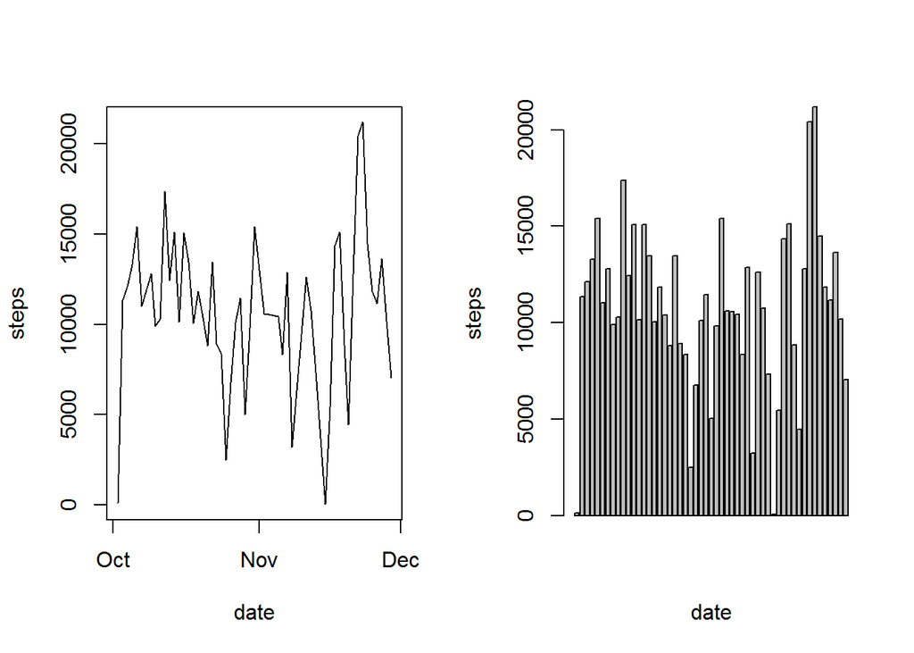

```r
par(mfrow = c(1, 2))
plot(total_steps_per_day, type = "l")
barplot(height = total_steps_per_day$steps, xlab = "date", ylab = "steps")
```

3. Average total number of steps taken per day is

```r
round(mean(total_steps_per_day$steps))
```

```
## [1] 10766
```

4. Median total number of steps taken per day is

```r
round(median(total_steps_per_day$steps))
```

```
## [1] 10765
```

## What is the average daily activity pattern?

1. Computing the aggregate information carrying the total number of steps treaded on each time-slot of the day

```r
total_steps_per_interval <- aggregate(formula = steps~interval, data = data, FUN = sum, na.rm=TRUE)
```

2. Time-series plot of the total number of steps taken in every interval is

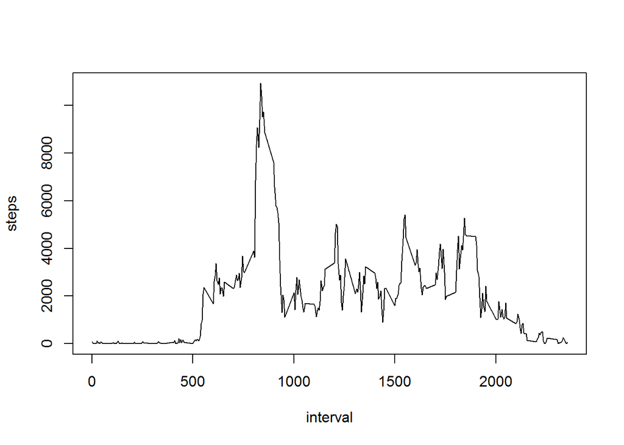

```r
plot(total_steps_per_interval, type = "l")
```

3. The 5-minute interval(s) during which the maximum number of steps were tread on a daily basis is

```r
total_steps_per_interval["interval"][total_steps_per_interval["steps"] == max(total_steps_per_interval$steps)]
```

```
## [1] 835
```

## Imputing missing values

- The *date* and *interval* columns have no unassigned values

```r
sum(is.na(data$date)) + sum(is.na(data$interval))
```

```
## [1] 0
```

- The NAs in the **steps** column are

```r
sum(is.na(data$steps))
```

```
## [1] 2304
```

- The strategy adopted to deal with *NAs* in the **steps** column is to fill them with the average number of steps tread over such an interval on any day

```r
non_na_days_count = nrow(total_steps_per_day)
average_steps_per_interval_per_day <- total_steps_per_interval
average_steps_per_interval_per_day$steps <- total_steps_per_interval$steps / non_na_days_count

cleaned_data <- read.csv(file = "activity.csv")
cleaned_data$date <- ymd(cleaned_data$date)

for (i in 1:nrow(cleaned_data))
{
    if(is.na(cleaned_data[i, "steps"]))
    {
        cleaned_data[i, "steps"] = average_steps_per_interval_per_day["steps"][average_steps_per_interval_per_day["interval"] == cleaned_data[i, "interval"]]
    }
}
```

- Computing the aggregate information carrying the total number of steps treaded on each day

```r
total_steps_per_day2 <- aggregate(formula = steps~date, data = cleaned_data, FUN = sum, na.rm=TRUE)
```

- Plot of the total number of steps treaded everyday

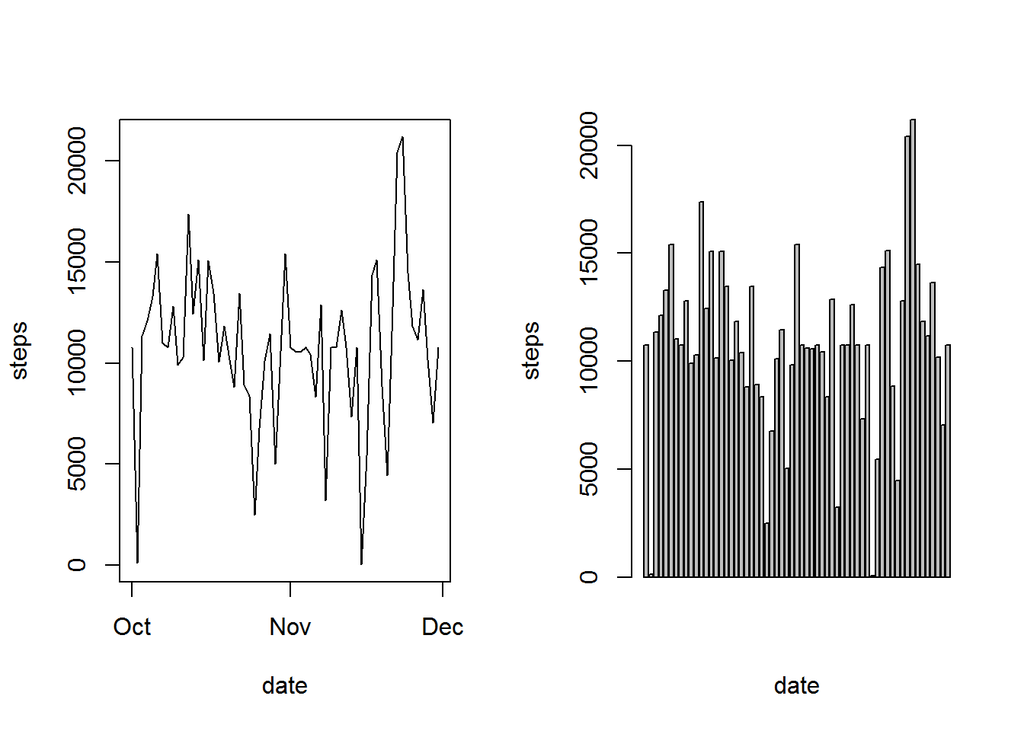

```r
par(mfrow = c(1, 2))
plot(total_steps_per_day2, type = "l")
barplot(height = total_steps_per_day2$steps, xlab = "date", ylab = "steps")
```

- Mean total number of steps taken per day is

```r
round(mean(total_steps_per_day2$steps))
```

```
## [1] 10766
```

- Median total number of steps taken per day is

```r
round(median(total_steps_per_day2$steps))
```

```
## [1] 10766
```

- The plots for total daily number of steps with the missing data and without the missing data are

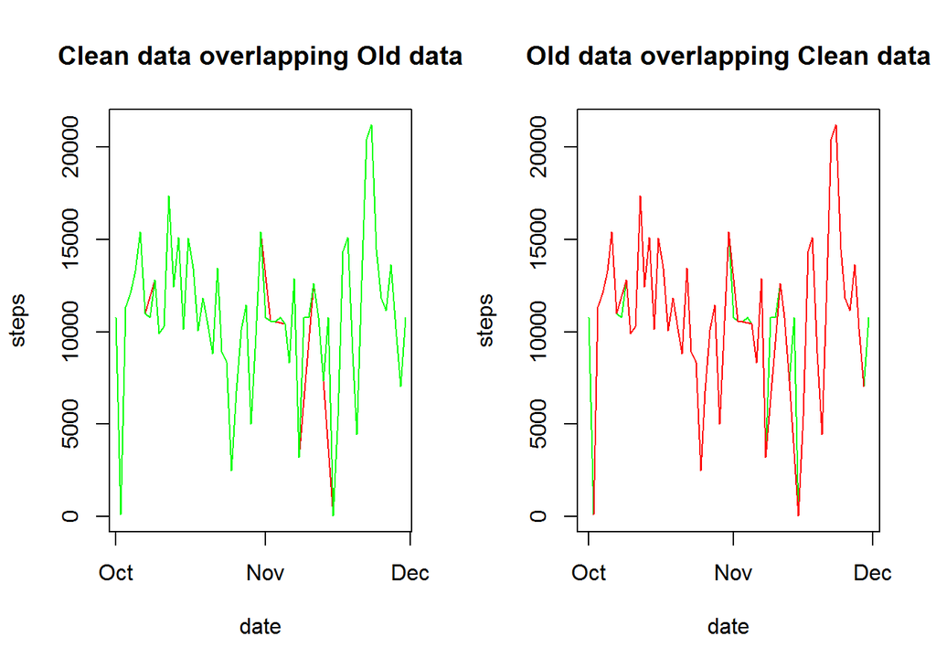

```r
par(mfrow = c(1, 2))
plot(total_steps_per_day, type = "l", col="red", main = "Clean data overlapping Old data")
lines(total_steps_per_day2, type = "l", col="green")
plot(total_steps_per_day2, type = "l", col="green", main = "Old data overlapping Clean data")
lines(total_steps_per_day, type = "l", col="red")
```

**From the heavy overlap, we can conclude that there’s only a small impact of imputing missing data on the estimates of the daily number of steps**

## Are there differences in activity patterns between weekdays and weekends?

- Creating the factor variable segregating the day as a weekday or a weekend

```r
cleaned_data$day_status <- ifelse(is.element(weekdays(cleaned_data$date), c("Saturday", "Sunday")), "weekend", "weekday")
cleaned_data$day_status <- as.factor(cleaned_data$day_status)
```

- Average number of steps treaded per interval on any weekday is

```r
average_steps_per_interval_on_weekday <- aggregate(formula = steps~interval, data = cleaned_data, subset = day_status == "weekday", FUN = mean, na.rm=TRUE)
```

- Average number of steps treaded per interval on any weekend is

```r
average_steps_per_interval_on_weekend <- aggregate(formula = steps~interval, data = cleaned_data, subset = day_status == "weekend", FUN = mean, na.rm=TRUE)
```

- The plots of the 5-minute interval and the average number of steps tread, averaged across all weekdays&weekends are

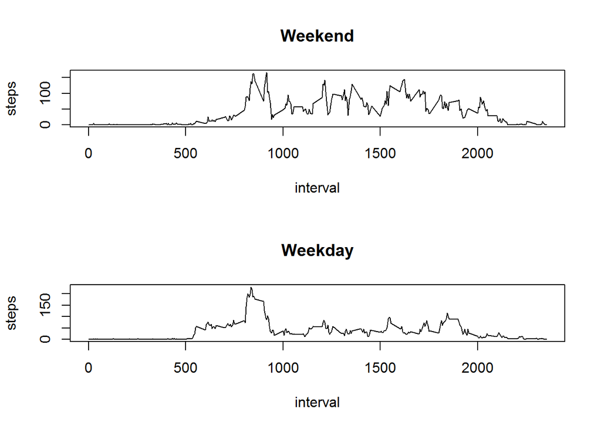

```r
par(mfrow = c(2, 1))
plot(average_steps_per_interval_on_weekend, type = "l", main = "Weekend")
plot(average_steps_per_interval_on_weekday, type = "l", main = "Weekday")
```